# Quiz 04 Answers

### Load required packages and files

```r
library(tidyverse)
library(rtracklayer)
library(ggseqlogo, lib = "~/")
library(Biostrings)
```

```r
fasta <- readDNAStringSet("yeast.fasta")

gff <- readGFFAsGRanges("saccharomyces_cerevisiae.gff.txt")
```

### 1. Using the genome annotation file, create a histogram of gene lengths of all `tRNA_gene`. (3 pt)

You could coerce the gff into a data frame, filter to tRNA genes, and plot it.

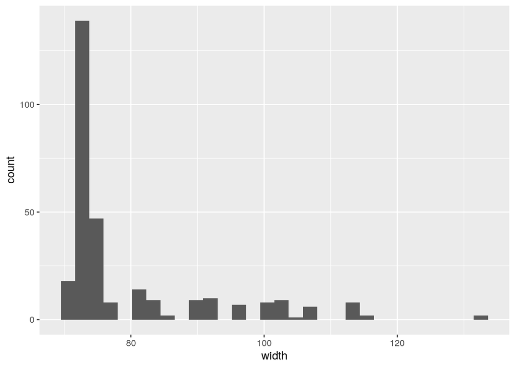

```r
gff %>%                           # take the gff
  as.data.frame() %>%             # make it a data frame
  filter(type == "tRNA_gene") %>% # get all the tRNA genes
  ggplot(., aes(width))+          # using the previous data frame (represented by the period), plot the width column
  geom_histogram()                # with a histogram
```

You could also pull the width column from the gff in a tidyverse manner and assign it to a variable, and plot that.

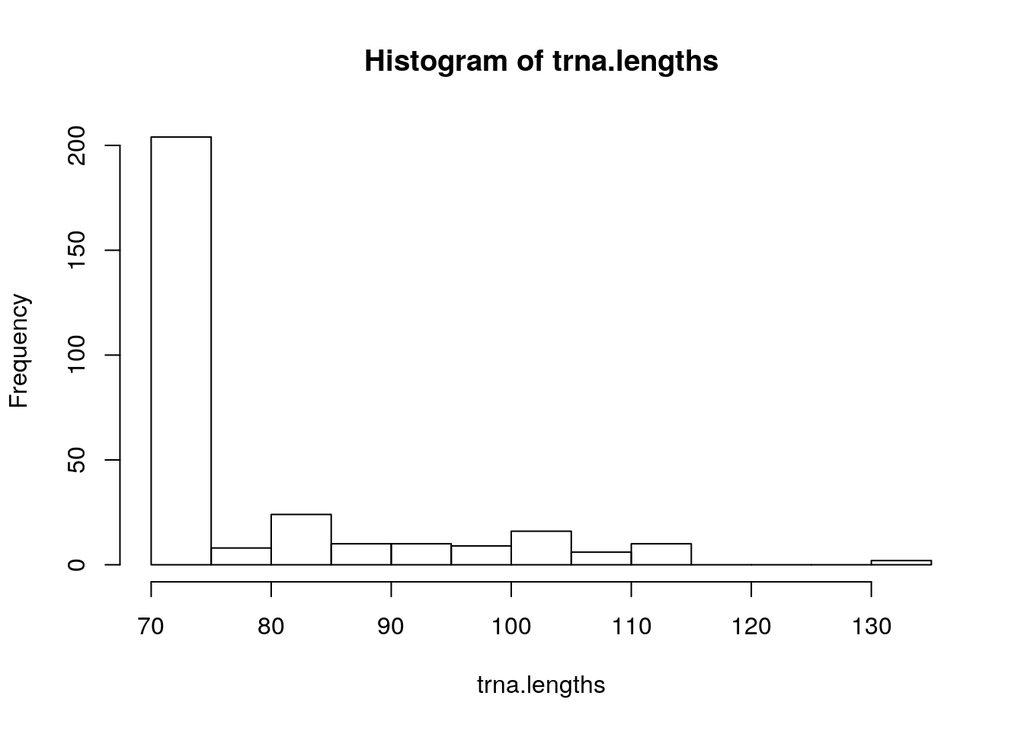

```r
trna.lengths <- gff %>%           # take the gff
  as.data.frame() %>%             # make it a data frame
  filter(type == "tRNA_gene") %>% # get all the tRNA genes
  pull(width)                     # pull the width column as a vector

hist(trna.lengths)                # plot a histogram of the vector trna.lengths
```

You could also extract the widths directly from the gff like this and plot those.

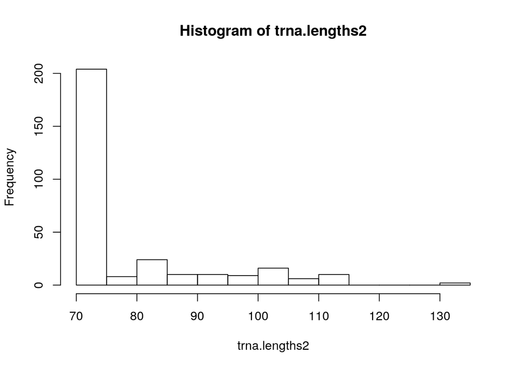

```r
trna.lengths2 <- width(gff[gff$type == "tRNA_gene"])

hist(trna.lengths2)
```